# Simulating Creel Surveys

Steven H. Ranney

2024-05-13

#Introduction

Creel surveys allow fisheries scientists and managers to collect data on catch and harvest, an angler population (including effort expended), and, depending on survey design, biological data on fish populations. Though important methods of collecting data on the user base of the fishery, creel surveys are difficult to implement and, in graduate fisheries programs, creel surveys are paid little attention. As a result, fisheries managers–the first job for many fisheries-program graduates–often inherit old surveys or are told to institute new surveys with little knowledge of how to do so.

Fisheries can cover large spatial extents: large reservoirs, coast-lines, and river systems. A creel survey has to be statistically valid, adaptable to the geographic challenges of the fishery, and cost efficient. Limited budgets can prevent agencies from implementing creel surveys; the AnglerCreelSurveySimulation was designed to help managers explore the type of creel survey that is most appropriate for their fishery, including fisheries with multiple access points, access points that are more popular than others, variation in catch rate, the number of surveyors, and seasonal variation in day-lengths.

The `AnglerCreelSurveySimulation` package is simple, but powerful. Four functions provide the means for users to create a population of anglers, limit the length of the fishing day to any value, and provide a mean trip length for the population. Ultimately, the user only needs to know the final function `ConductMultipleSurveys` but because I’d rather this *not* be a *black box* of functions, this brief introduction will be a step-by-step process through the package.

##A walk-through of the package

This tutorial assumes that we have a very simple, small fishery with only one access point that, on any given day, is visited by 100 anglers. The fishing day length for our theoretical fishery is 12 hours (say, from 6 am to 6pm) and all anglers are required to have completed their trip by 6pm. Lastly, the mean trip length is known to be 3.5 hours.

*For the purposes of this package, all times are functions of the fishing day. In other words, if a fishing day length is 12 hours (e.g., from 6 am to 6pm) and an angler starts their trip at `2` and ends at `4` that means that they started their trip at 8 am and ended at 10 am.*

The `make_anglers()` function builds a population of anglers:

```r
library(AnglerCreelSurveySimulation)

anglers <- make_anglers(n_anglers = 100, mean_trip_length = 3.5, fishing_day_length = 12)
```

`make_anglers()` returns a dataframe with `start_time`, `trip_length`, and `departure_time` for all anglers.

```r
head(anglers)
```

```
#>   start_time trip_length departure_time
#> 1   7.238159    1.325826       8.563985
#> 2   2.953622    2.235586       5.189208
#> 3   7.676914    3.436153      11.113067
#> 4   3.097302    4.638618       7.735920
#> 5   1.284245    3.321098       4.605344
#> 6   7.974742    1.633840       9.608582
```

The distribution of angler trip lengths can be easily visualized:

```r
library(dplyr)
```

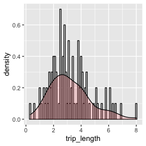

```r
library(ggplot2)

# Histogram overlaid with kernel density curve
anglers %>%
  ggplot(aes(x=trip_length)) +
  geom_histogram(aes(y=..density..),
                 binwidth=.1,
                 colour="black", fill="white") +
  geom_density(alpha=.2, fill="#FF6666")
```

Once the population of anglers has been created, the next function to apply is the `get_total_values()` function. In `get_total_values()`, the user specifies the start time of the creel surveyor, the end time of the surveyor, and the wait time of the surveyor. Here is where the user also specifies the sampling probability of the anglers (in most cases, equal to $\frac{waitTime}{fishingDayLength}$) and the mean catch rate of the fishery. There are a number of a default settings in the `get_total_values()` function; see `?get_total_values` for a description of how the function handles `NULL` values for `startTime`, `endTime`, and `waitTime`. `startTime` and `waitTime` are the times that the surveyor started and waited at the access point. `totalCatch` and `trueEffort` are the total (or *real*) values for catch and effort. `meanLambda` is the mean catch rate for all anglers. Even though we assigned `meanCatchRate` to `get_total_values()`, individual mean catch rates are simulated by `rgamma()` with shape equal to `meanCatchRate` and rate equal to `1`.

For this walk through, we’ll schedule the surveyor to work for a total of eight hours at the sole access point in our fishery:

```r
anglers %>%
  get_total_values(start_time = 0, wait_time = 8, sampling_prob = 8/12, mean_catch_rate = 2.5)
```

```
#>   n_observed_trips total_observed_trip_effort n_completed_trips
#> 1               91                   378.9607                61
#>   total_completed_trip_effort total_completed_trip_catch start_time wait_time
#> 1                    275.0163                   670.2935          0         8
#>   total_catch true_effort mean_lambda
#> 1    900.8161    318.3179    2.700503
```

`get_total_values()` returns a single row data frame with several columns. The output of `get_total_values()` is the catch and effort data observed by the surveyor during their wait at the access point along with the “true” values for catch and effort. (Obviously, we can’t simulate biological data but, if an agency’s protocol directed the surveyor to collect biological data, that could be analyzed with other `R` functions.)

In the output from `get_total_values()`, `n_observed_trips` is the number of trips that the surveyor observed, including anglers that arrived after she started her day and anglers that were there for the duration of her time at the access point. `total_observed_trip_effort` is the effort expended by those parties; because the observed trips were not complete, she did not count their catch. `n_completed_trips` is the number of anglers that completed their trips while she was onsite, `total_completed_trip_effort` is the effort expended by those anglers, and `total_completed_trip_catch` is the number of fish caught by those parties. Catch is both the number of fish harvested and those caught and released.

### Estimating catch and effort

Effort and catch are estimated from the Bus Route Estimator:

$$\widehat{E} =
T\sum\limits_{i=1}^n{\frac{1}{w_{i}}}\sum\limits_{j=1}^m{\frac{e_{ij}}{\pi_{j}}}$$

where

- *E* = estimated total party-hours of effort;
- *T* = total time to complete a full circuit of the route, including traveling and waiting;
- *w<sub>i</sub>* = waiting time at the *i<sup>th</sup>* site (where *i* = 1, …, *n* sites);

and

- *e<sub>ij</sub>* = total time that the *j<sup>th</sup>* car (or trailer) is parked at the *i<sup>th</sup>* site while the agent is at that site (where *j* = 1, …, *n* sites).

Catch rate is calculated from the Ratio of Means equation:

$$\widehat{R_1} =
\frac{\sum\limits_{i=1}^n{c_i/n}}{\sum\limits_{i=1}^n{L_i/n}}$$

where

- *c<sub>i</sub>* is the catch for the *i<sup>th</sup>* sampling unit

and  
* *L<sub>i</sub>* is the length of the fishing trip at the tie of the interview.

For incomplete surveys, *L<sub>i</sub>* represents an incomplete trip.

`simulate_bus_route()` calculates effort and catch based upon these equations. See `?simulate_bus_route` for references that include a more detailed discussion of these equations.

`simulate_bus_route()` calls `make_anglers()` and `get_total_values()` so many of the same arguments we passed in the previous functions will need to be passed to `simulate_bus_route()`. The new argument, `nsites`, is the number of sites visited by the surveyor. In more advanced simulations (see the examples in `?simulate_bus_route`), you can pass strings of values for `startTime`, `waitTime`, `nsites`, and `nanglers` to simulate a bus route-type survey rather than just a single access-point survey.

```r
sim <- simulate_bus_route(start_time = 0, wait_time = 8, n_sites = 1, n_anglers = 100,
                          sampling_prob = 8/12, mean_catch_rate = 2.5, fishing_day_length = 12)

sim
```

```
#>      Ehat catch_rate_ROM true_catch true_effort mean_lambda
#> 1 409.936       2.297963   891.6496    346.0502    2.613442
```

The output from `simulate_bus_route()` is a dataframe with values for `Ehat`, `catchRateROM` (the ratio of means catch rate), `trueCatch`, `trueEffort`, and `meanLambda`. `Ehat` is the estimated total effort from the Bus Route Estimator above and `catchRateROM` is catch rate estimated from the Ratio of Means equation. `trueCatch`, `trueEffort`, and `meanLambda` are the same as before. Multiplying `Ehat` by `catchRateROM` gives an estimate of total catch: 942.0178635.

###Conducting multiple simulations

With information about the fishery, the start and wait times of the surveyor, the sampling probability, mean catch rate, and fishing day length, we can run multiple simulations with `conduct_multiple_surveys()`. `conduct_multiple_surveys()` is a wrapper that calls the other three functions in turn and compiles the values into a data frame for easy plotting or analysis. The only additional argument needed is the `nsims` value which tells the function how many simulations to conduct. For the sake of this simple simulation, let’s assume that the creel survey works five days a week for four weeks (i.e. 20 days):

```r
sim <- conduct_multiple_surveys(n_sims = 20, start_time = 0, wait_time = 8, n_sites = 1,
                                n_anglers = 100, sampling_prob = 8/12,
                                mean_catch_rate = 2.5, fishing_day_length = 12)

sim
```

```
#>        Ehat catch_rate_ROM true_catch true_effort mean_lambda
#> 1  376.6182       2.519242   846.7200    344.3344    2.472871
#> 2  389.6775       2.601564   854.0753    357.5443    2.383879
#> 3  384.5418       2.328529   762.5164    355.8506    2.238003
#> 4  388.2216       2.436591   861.6960    366.4591    2.354099
#> 5  371.1078       2.477710   814.2975    331.1943    2.340942
#> 6  370.7990       2.658424   903.5185    331.8732    2.625328
#> 7  384.1850       2.612345   906.0439    354.0076    2.578438
#> 8  407.0480       2.607874   948.4486    377.0258    2.550014
#> 9  361.4820       2.483589   858.0846    334.9782    2.564525
#> 10 375.5050       2.380012   956.6329    332.0240    2.811077
#> 11 341.9553       2.172521   910.1723    323.4882    2.643072
#> 12 386.8595       2.416742   915.9138    351.6712    2.603038
#> 13 389.1150       2.312806   854.3322    343.8923    2.520057
#> 14 409.8340       2.698748  1017.0248    376.4917    2.739232
#> 15 348.4828       2.288811   826.0451    326.5319    2.552013
#> 16 360.1970       2.405245   688.5132    313.6174    2.265548
#> 17 319.0463       3.075032   889.4199    321.9518    2.715001
#> 18 402.2221       2.758371   920.2525    356.7515    2.559893
#> 19 429.0461       2.642780  1034.2358    371.3453    2.782377
#> 20 400.7477       2.478225   958.3914    353.0512    2.764598
```

With the output from multiple simulations, an analyst can evaluate how closely the creel survey they’ve designed mirrors reality. A `lm()` of estimated catch as a function of `trueCatch` can tell us if the survey will over or under estimate reality:

```r
mod <-
  sim %>%
  lm((Ehat * catch_rate_ROM) ~ true_catch, data = .)

summary(mod)
```

```
#>
#> Call:
#> lm(formula = (Ehat * catch_rate_ROM) ~ true_catch, data = .)
#>
#> Residuals:
#>     Min      1Q  Median      3Q     Max
#> -231.14  -34.39   18.92   53.95  128.04
#>
#> Coefficients:
#>             Estimate Std. Error t value Pr(>|t|)
#> (Intercept) 306.7721   210.0432   1.461   0.1614
#> true_catch    0.7331     0.2361   3.106   0.0061 **
#> ---
#> Signif. codes:  0 '***' 0.001 '**' 0.01 '*' 0.05 '.' 0.1 ' ' 1
#>
#> Residual standard error: 83.31 on 18 degrees of freedom
#> Multiple R-squared:  0.3489, Adjusted R-squared:  0.3127
#> F-statistic: 9.646 on 1 and 18 DF,  p-value: 0.006101
```

Plotting the data and the model provide a good visual means of evaluating how close our estimates are to reality:

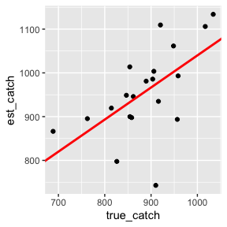

```r
#Create a new vector of the estimated effort multiplied by estimated catch rate
sim <-
  sim %>%
  mutate(est_catch = Ehat * catch_rate_ROM)

sim %>%
  ggplot(aes(x = true_catch, y = est_catch)) +
  geom_point() +
  geom_abline(intercept = mod$coefficients[1], slope = mod$coefficients[2],
              colour = "red", size = 1.01)
```

The closer the slope parameter estimate is to 1 and the intercept parameter estimate is to 0, the closer our estimate of catch is to reality.

We can create a model and plot of our effort estimates, too:

```r
mod <-
  sim %>%
  lm(Ehat ~ true_effort, data = .)

summary(mod)
```

```
#>
#> Call:
#> lm(formula = Ehat ~ true_effort, data = .)
#>
#> Residuals:
#>     Min      1Q  Median      3Q     Max
#> -32.311  -7.028  -2.247  10.501  19.691
#>
#> Coefficients:
#>             Estimate Std. Error t value Pr(>|t|)
#> (Intercept) -26.6792    55.8474  -0.478    0.639
#> true_effort   1.1742     0.1611   7.289 8.98e-07 ***
#> ---
#> Signif. codes:  0 '***' 0.001 '**' 0.01 '*' 0.05 '.' 0.1 ' ' 1
#>
#> Residual standard error: 13.19 on 18 degrees of freedom
#> Multiple R-squared:  0.7469, Adjusted R-squared:  0.7329
#> F-statistic: 53.13 on 1 and 18 DF,  p-value: 8.982e-07
```

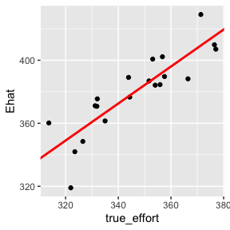

```r
#Create a new vector of the estimated effort multiplied by estimated catch rate

sim %>%
  ggplot(aes(x = true_effort, y = Ehat)) +
  geom_point() +
  geom_abline(intercept = mod$coefficients[1], slope = mod$coefficients[2],
              colour = "red", size = 1.01)
```

### Can we observe ALL trips?

If the start and wait time equals 0 and the length of the fishing day, respectively, the creel surveyor can observe all completed trips, though she’d likely be unhappy having to work 12 hours. The inputs have to be adjusted to allow her to arrive at time 0, stay for all 12 hours, and have a probability of 1.0 at catching everyone:

```r
start_time <- 0
wait_time <- 12
sampling_prob <- 1

sim <- conduct_multiple_surveys(n_sims = 20, start_time = start_time, wait_time = wait_time,
                                n_sites = 1, n_anglers = 100, sampling_prob = 1,
                                mean_catch_rate = 2.5, fishing_day_length = 12)

sim
```

```
#>        Ehat catch_rate_ROM true_catch true_effort mean_lambda
#> 1  331.5126       2.258124   748.5965    331.5126    2.226366
#> 2  335.3444       2.284950   766.2451    335.3444    2.418218
#> 3  333.6399       2.478427   826.9022    333.6399    2.440359
#> 4  317.0329       2.325350   737.2123    317.0329    2.357007
#> 5  297.0303       2.117019   628.8189    297.0303    2.143518
#> 6  324.3639       2.299249   745.7935    324.3639    2.378997
#> 7  322.9534       2.628027   848.7302    322.9534    2.683393
#> 8  340.1983       2.882697   980.6887    340.1983    2.686978
#> 9  370.5029       2.368574   877.5637    370.5029    2.436295
#> 10 344.4279       2.440527   840.5856    344.4279    2.305974
#> 11 336.1316       2.317123   778.8581    336.1316    2.203803
#> 12 356.4815       2.628166   936.8928    356.4815    2.489206
#> 13 323.4428       2.317091   749.4464    323.4428    2.336160
#> 14 332.7596       2.510335   835.3380    332.7596    2.552702
#> 15 330.2695       2.576715   851.0104    330.2695    2.616000
#> 16 326.6618       2.331027   761.4574    326.6618    2.240301
#> 17 336.2574       2.279683   766.5603    336.2574    2.311405
#> 18 351.5997       2.561353   900.5711    351.5997    2.507581
#> 19 351.4495       2.212520   777.5890    351.4495    2.193988
#> 20 319.4902       2.598769   830.2811    319.4902    2.577867
```

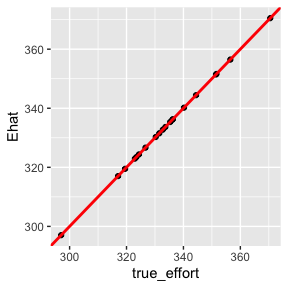

### Another simulation

If our hypothetical fishery suddenly gained another access point and the original 100 anglers were split between the two access points equally, what kind of information would a creel survey capture? We could ask our surveyor to split her eight-hour work day between both access points, but she’ll have to drive for 0.5 hours to get from one to another. Of course, that 0.5 hour of drive time will be a part of her work day so she’ll effectively have 7.5 hours to spend at access points counting anglers and collecting data.

```r
start_time <- c(0, 4.5)
wait_time <- c(4, 3.5)
n_sites = 2
n_anglers <- c(50, 50)
fishing_day_length <- 12
sampling_prob <- sum(wait_time)/fishing_day_length

sim <- conduct_multiple_surveys(n_sims = 20, start_time = start_time, wait_time = wait_time,
                                n_sites = n_sites, n_anglers = n_anglers,
                                sampling_prob = sampling_prob, mean_catch_rate = 2.5,
                                fishing_day_length = fishing_day_length)

sim
```

```
#>        Ehat catch_rate_ROM true_catch true_effort mean_lambda
#> 1  492.8639       1.722646   715.5206    329.7062    2.294514
#> 2  528.2219       2.519027   800.9620    348.0565    2.309510
#> 3  499.8952       2.689286   792.5064    329.5931    2.426154
#> 4  511.1506       2.264724   822.7999    338.4422    2.507654
#> 5  563.1956       2.537964   827.5075    356.8933    2.256187
#> 6  530.4618       2.721845   900.7757    354.8364    2.618954
#> 7  531.3834       2.564764   922.5139    334.9887    2.728519
#> 8  466.0805       2.553252   792.5782    323.5327    2.496906
#> 9  455.9357       2.632786   916.5352    346.0207    2.700286
#> 10 493.1137       2.051125   874.1247    344.6554    2.563315
#> 11 550.3458       2.304537   860.5337    349.7014    2.322299
#> 12 610.5815       2.582332   827.6661    342.4361    2.471889
#> 13 528.3076       2.117544   965.1213    353.1666    2.676699
#> 14 599.3215       2.707865   904.5747    357.7262    2.553898
#> 15 634.6256       1.912975   947.1593    374.6526    2.510612
#> 16 456.4338       2.544216   829.7986    349.9623    2.279834
#> 17 598.5900       2.847658   869.0655    352.3398    2.483211
#> 18 561.8719       2.807523   872.9477    339.3835    2.503308
#> 19 492.0098       3.105794   924.5582    378.8442    2.386399
#> 20 399.4990       1.967737   753.2112    314.8620    2.365910
```

[output not shown]

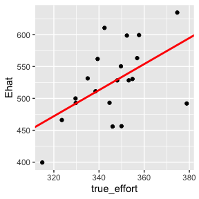

### Even more simulations

```r
#Weekend clerks
start_time_w <- 2
wait_time_w <- 10
n_sites <- 1
n_anglers_w <- 75
fishing_day_length <- 12
sampling_prob <- 8/12

sim_w <- conduct_multiple_surveys(n_sims = 8, start_time = start_time_w,
                                  wait_time = wait_time_w, n_sites = n_sites,
                                  n_anglers = n_anglers_w, sampling_prob = sampling_prob,
                                  mean_catch_rate = 2.5, fishing_day_length = fishing_day_length)

sim_w
```

```
#>       Ehat catch_rate_ROM true_catch true_effort mean_lambda
#> 1 388.6103       2.667906   692.7806    260.4893    2.623400
#> 2 369.6578       2.410091   595.8737    247.4235    2.453790
#> 3 384.4043       2.516820   644.9844    256.2695    2.540813
#> 4 363.7742       2.508243   608.2893    242.5161    2.558225
#> 5 387.8980       2.826352   732.8723    259.5569    2.788018
#> 6 411.5632       2.243179   616.6394    275.0917    2.221008
#> 7 327.9949       2.410986   529.8627    220.0829    2.331251
#> 8 337.2557       2.694240   614.5451    229.6741    2.578197
```

```r
#Add the weekday survey and weekend surveys to the same data frame
mon_survey <-
  sim_w %>%
  bind_rows(sim)

mod <-
  mon_survey %>%
  lm(Ehat ~ true_effort, data = .)

summary(mod)
```

```
#>
#> Call:
#> lm(formula = Ehat ~ true_effort, data = .)
#>
#> Residuals:
#>     Min      1Q  Median      3Q     Max
#> -87.279  -9.576   0.543  18.509  90.195
#>
#> Coefficients:
#>             Estimate Std. Error t value Pr(>|t|)
#> (Intercept) -33.6183    56.2029  -0.598    0.555
#> true_effort   1.6178     0.1747   9.258 1.03e-09 ***
#> ---
#> Signif. codes:  0 '***' 0.001 '**' 0.01 '*' 0.05 '.' 0.1 ' ' 1
#>
#> Residual standard error: 43.06 on 26 degrees of freedom
#> Multiple R-squared:  0.7673, Adjusted R-squared:  0.7583
#> F-statistic: 85.72 on 1 and 26 DF,  p-value: 1.028e-09
```

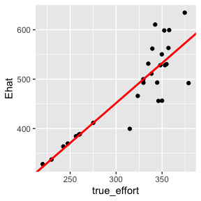

### Choose your own adventure

Hopefully, this vignette has shown you how to build and simulate your own creel survey. It’s flexible enough to estimate monthly or seasonal changes in fishing day length, changes in the mean catch rate, increased angler pressure on weekends, and any number of access sites, start times, wait times, and sampling probabilities. The output from `conduct_multiple_surveys()` allows the user to estimate variability in the catch and effort estimates (e.g., relative standard error) to evaluate the most efficient creel survey for *their* fishery.